# Relatório 2 – Análise Estatística

Flávia Alves

01/09/2026

# 1 1. Introdução

Este relatório apresenta uma análise estatística de um banco de dados composto por 1.000 alunos de uma escola pública brasileira.

O banco de dados foi construído para proporcionar uma experiência prática de análise estatística, envolvendo informações relacionadas à frequência escolar, ao desempenho acadêmico e a características sociofamiliares dos estudantes.

São analisadas cinco variáveis: número de faltas, nota média, turno de estudo, escolaridade da mãe e acesso à internet em casa.

O objetivo deste trabalho é explorar os dados, realizar análises univariadas, bivariadas e multivariadas e responder às questões investigativas propostas, buscando identificar possíveis relações entre as características dos estudantes e seu desempenho escolar.

# 2 2. Banco de dados

O banco de dados utilizado neste relatório é o arquivo `dados_alunos.csv`.

As cinco variáveis analisadas são:

- **Faltas:** número de ausências do aluno durante o ano letivo;
- **Nota média:** desempenho acadêmico médio do aluno;
- **Turno:** período em que o aluno estuda;
- **Escolaridade da mãe:** nível de escolaridade da mãe;
- **Acesso à internet:** existência ou não de acesso à internet em casa.

Segundo as orientações da atividade, as variáveis são classificadas da seguinte forma:

- Faltas: quantitativa discreta;
- Nota média: quantitativa contínua;
- Turno: qualitativa nominal;
- Escolaridade da mãe: qualitativa ordinal;
- Acesso à internet: qualitativa nominal.

## 2.1 2.1 Importação dos dados

O banco de dados utiliza ponto e vírgula como separador entre as colunas e vírgula como separador decimal.

O arquivo `dados_alunos.csv` deve estar na mesma pasta do arquivo `index.Rmd`.

```r
arquivos_possiveis <- c("dados_alunos.csv", "dados_alunos (1).csv")
arquivos_possiveis <- arquivos_possiveis[file.exists(arquivos_possiveis)]

if (length(arquivos_possiveis) == 0) {
  stop("Nenhum arquivo de dados foi encontrado na pasta do relatório.")
}

arquivo_dados <- NULL

for (arq in arquivos_possiveis) {
  primeira_linha <- tryCatch(
    readLines(arq, n = 1, warn = FALSE),
    error = function(e) ""
  )

  if (grepl("faltas", primeira_linha, ignore.case = TRUE) &&
      grepl("nota_media", primeira_linha, ignore.case = TRUE) &&
      grepl("turno", primeira_linha, ignore.case = TRUE) &&
      grepl("escolaridade_mae", primeira_linha, ignore.case = TRUE) &&
      grepl("acesso_internet", primeira_linha, ignore.case = TRUE)) {
    arquivo_dados <- arq
    break
  }
}

if (is.null(arquivo_dados)) {
  stop("Nenhum dos arquivos CSV encontrados possui as colunas esperadas.")
}

dados_alunos <- read.csv2(
  arquivo_dados,
  header = TRUE,
  sep = ";",
  dec = ",",
  stringsAsFactors = FALSE,
  check.names = FALSE
)

dados_alunos$faltas <- as.numeric(dados_alunos$faltas)
dados_alunos$nota_media <- as.numeric(dados_alunos$nota_media)

if (!all(c(
  "faltas",
  "nota_media",
  "turno",
  "escolaridade_mae",
  "acesso_internet"
) %in% names(dados_alunos))) {
  stop("As colunas esperadas não foram encontradas.")
}
```

## 2.2 2.2 Verificação inicial do banco

As primeiras linhas do banco de dados são apresentadas abaixo.

```r
head(dados_alunos)
```

```
##   faltas nota_media      turno escolaridade_mae acesso_internet
## 1     11       10.0 Vespertino            Médio             Sim
## 2      8        8.3   Matutino      Fundamental             Sim
## 3      9        9.2 Vespertino      Fundamental             Sim
## 4      7        5.8   Matutino            Médio             Sim
## 5      7        8.6 Vespertino      Fundamental             Não
## 6     16        5.3 Vespertino            Médio             Sim
```

A dimensão do banco é:

```r
dim(dados_alunos)
```

```
## [1] 1000    5
```

Os nomes das variáveis são:

```r
names(dados_alunos)
```

```
## [1] "faltas"           "nota_media"       "turno"            "escolaridade_mae"
## [5] "acesso_internet"
```

Também será realizada uma verificação da estrutura dos dados.

```r
str(dados_alunos)
```

```
## 'data.frame':    1000 obs. of  5 variables:
##  $ faltas          : num  11 8 9 7 7 16 12 7 8 7 ...
##  $ nota_media      : num  10 8.3 9.2 5.8 8.6 5.3 7.8 6.7 5.5 7.3 ...
##  $ turno           : chr  "Vespertino" "Matutino" "Vespertino" "Matutino" ...
##  $ escolaridade_mae: chr  "Médio" "Fundamental" "Fundamental" "Médio" ...
##  $ acesso_internet : chr  "Sim" "Sim" "Sim" "Sim" ...
```

O banco possui 1000 alunos e 5 variáveis.

Será verificada também a existência de valores ausentes.

```r
colSums(is.na(dados_alunos))
```

```
##           faltas       nota_media            turno escolaridade_mae
##                0                0                0                0
##  acesso_internet
##                0
```

# 3 3. Análise Univariada

A análise univariada consiste em estudar cada variável individualmente.

## 3.1 3.1 Número de faltas

A variável faltas representa o número de ausências de cada aluno durante o ano letivo. Trata-se de uma variável quantitativa discreta.

### 3.1.1 Medidas estatísticas

```r
summary(dados_alunos$faltas)
```

```
##    Min. 1st Qu.  Median    Mean 3rd Qu.    Max.
##   1.000   6.000   8.000   8.013  10.000  19.000
```

A média de faltas é:

```r
mean(dados_alunos$faltas, na.rm = TRUE)
```

```
## [1] 8.013
```

A mediana é:

```r
median(dados_alunos$faltas, na.rm = TRUE)
```

```
## [1] 8
```

O desvio-padrão é:

```r
sd(dados_alunos$faltas, na.rm = TRUE)
```

```
## [1] 2.79869
```

O menor e o maior número de faltas são:

```r
min(dados_alunos$faltas, na.rm = TRUE)
```

```
## [1] 1
```

```r
max(dados_alunos$faltas, na.rm = TRUE)
```

```
## [1] 19
```

A média de faltas observada foi de **8.01 faltas**.

A mediana foi de **8 faltas**.

O menor número de faltas observado foi **1**, enquanto o maior foi **19**.

### 3.1.2 Distribuição das faltas

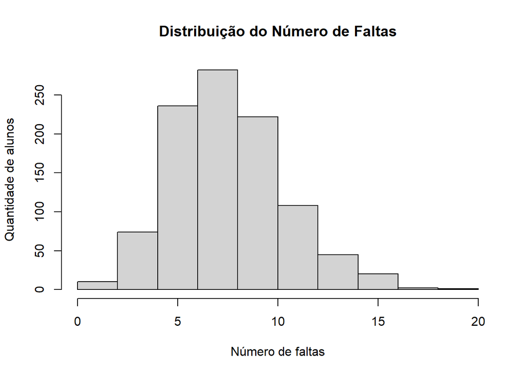

```r
hist(
  dados_alunos$faltas,
  main = "Distribuição do Número de Faltas",
  xlab = "Número de faltas",
  ylab = "Quantidade de alunos"
)
```

O histograma permite observar a distribuição do número de faltas entre os alunos.

## 3.2 3.2 Nota média

A nota média representa o desempenho acadêmico dos estudantes e é uma variável quantitativa contínua.

### 3.2.1 Medidas estatísticas

```r
summary(dados_alunos$nota_media)
```

```
##    Min. 1st Qu.  Median    Mean 3rd Qu.    Max.
##   0.500   5.200   6.500   6.444   7.700  10.000
```

A média das notas é:

```r
mean(dados_alunos$nota_media, na.rm = TRUE)
```

```
## [1] 6.4438
```

A mediana é:

```r
median(dados_alunos$nota_media, na.rm = TRUE)
```

```
## [1] 6.5
```

O desvio-padrão é:

```r
sd(dados_alunos$nota_media, na.rm = TRUE)
```

```
## [1] 1.882463
```

O menor e o maior valor são:

```r
min(dados_alunos$nota_media, na.rm = TRUE)
```

```
## [1] 0.5
```

```r
max(dados_alunos$nota_media, na.rm = TRUE)
```

```
## [1] 10
```

A nota média geral dos alunos foi de **6.44 pontos**.

A mediana foi de **6.5 pontos**.

A menor nota observada foi **0.5**, enquanto a maior foi **10**.

### 3.2.2 Distribuição das notas

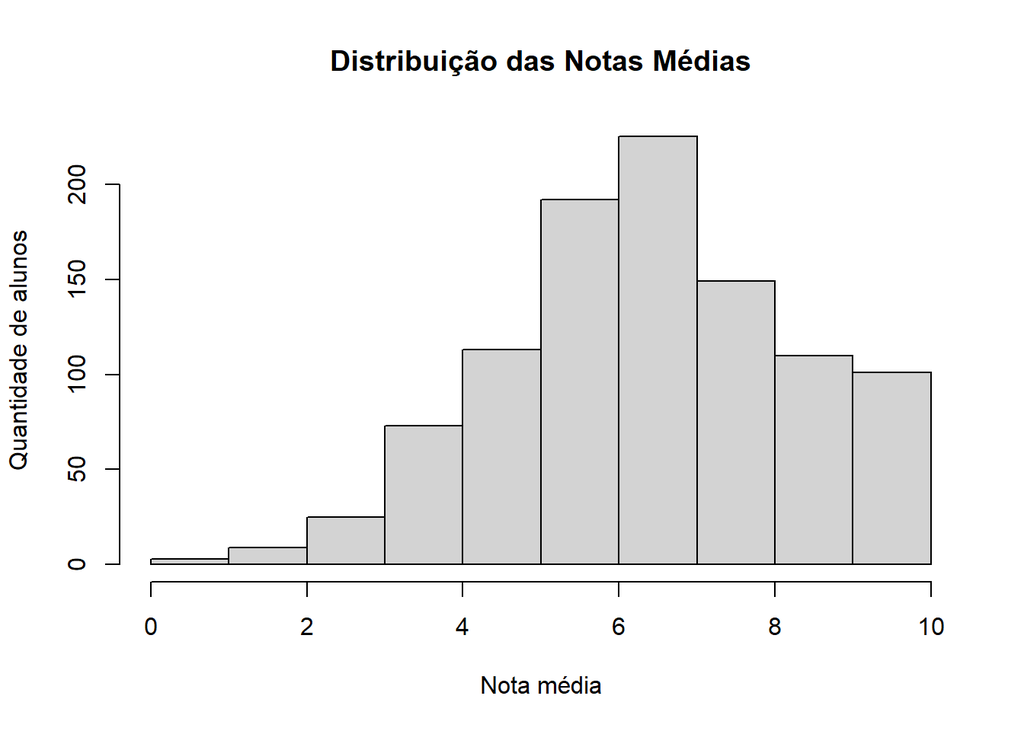

```r
hist(
  dados_alunos$nota_media,
  main = "Distribuição das Notas Médias",
  xlab = "Nota média",
  ylab = "Quantidade de alunos"
)
```

O histograma permite visualizar como as notas estão distribuídas entre os estudantes.

## 3.3 3.3 Turno de estudo

A variável turno é qualitativa nominal e possui as categorias Matutino, Vespertino e Noturno.

### 3.3.1 Frequência

```r
table(dados_alunos$turno)
```

```
##
##   Matutino    Noturno Vespertino
##        451        204        345
```

### 3.3.2 Percentual

```r
round(prop.table(table(dados_alunos$turno)) * 100, 2)
```

```
##
##   Matutino    Noturno Vespertino
##       45.1       20.4       34.5
```

### 3.3.3 Gráfico

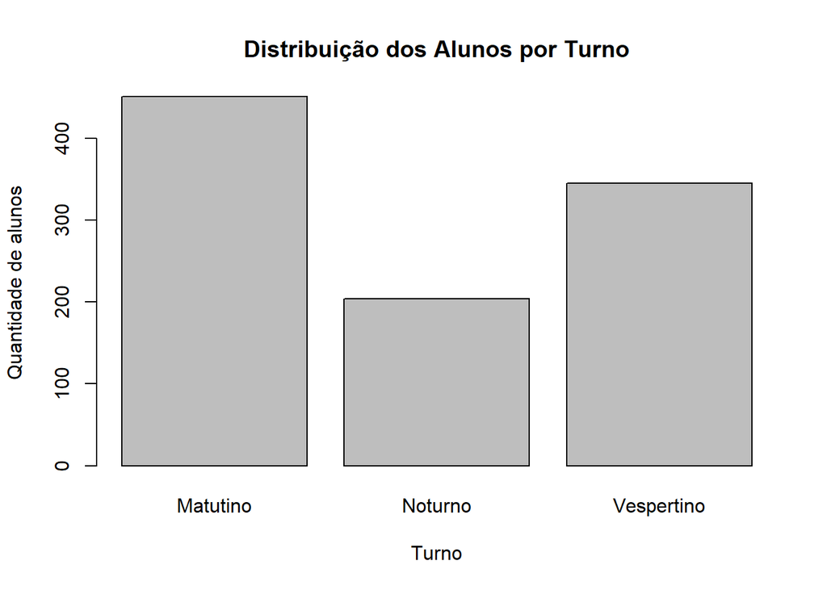

```r
barplot(
  table(dados_alunos$turno),
  main = "Distribuição dos Alunos por Turno",
  xlab = "Turno",
  ylab = "Quantidade de alunos"
)
```

A análise permite verificar como os alunos estão distribuídos entre os diferentes turnos.

## 3.4 3.4 Escolaridade da mãe

A escolaridade da mãe é uma variável qualitativa ordinal, pois existe uma ordem natural entre as categorias Fundamental, Médio e Superior.

### 3.4.1 Frequência

```r
table(dados_alunos$escolaridade_mae)
```

```
##
## Fundamental       Médio    Superior
##         391         459         150
```

### 3.4.2 Percentual

```r
round(prop.table(table(dados_alunos$escolaridade_mae)) * 100, 2)
```

```
##
## Fundamental       Médio    Superior
##        39.1        45.9        15.0
```

### 3.4.3 Gráfico

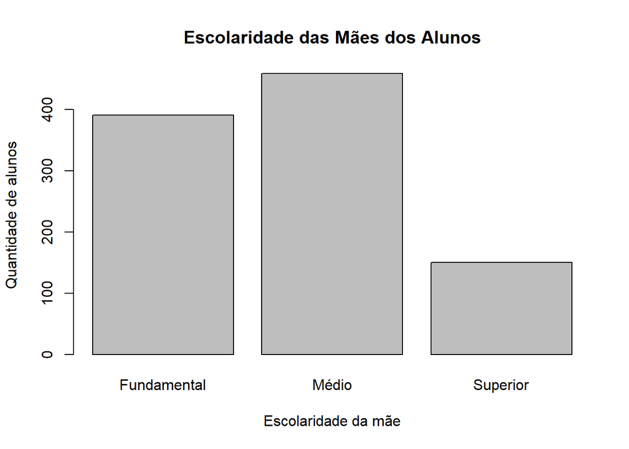

```r
barplot(
  table(dados_alunos$escolaridade_mae),
  main = "Escolaridade das Mães dos Alunos",
  xlab = "Escolaridade da mãe",
  ylab = "Quantidade de alunos"
)
```

A distribuição permite conhecer o nível de escolaridade das mães dos alunos participantes do estudo.

## 3.5 3.5 Acesso à internet em casa

A variável acesso à internet é qualitativa nominal e possui as categorias Sim e Não.

### 3.5.1 Frequência

```r
table(dados_alunos$acesso_internet)
```

```
##
## Não Sim
## 297 703
```

### 3.5.2 Percentual

```r
round(prop.table(table(dados_alunos$acesso_internet)) * 100, 2)
```

```
##
##  Não  Sim
## 29.7 70.3
```

### 3.5.3 Gráfico

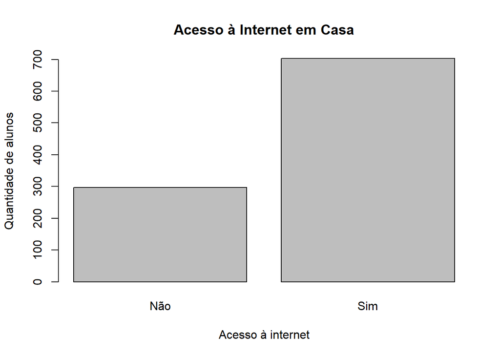

```r
barplot(
  table(dados_alunos$acesso_internet),
  main = "Acesso à Internet em Casa",
  xlab = "Acesso à internet",
  ylab = "Quantidade de alunos"
)
```

A análise permite verificar a proporção de alunos que possuem ou não acesso à internet em casa.

# 4 4. Análise Bivariada

Na análise bivariada são estudadas relações entre duas variáveis.

## 4.1 4.1 Acesso à internet e nota média

A primeira questão investigativa procura verificar se os alunos com acesso à internet em casa apresentam notas médias significativamente maiores.

Primeiramente, serão calculadas as médias das notas para os dois grupos.

```r
media_internet <- tapply(
  dados_alunos$nota_media,
  dados_alunos$acesso_internet,
  mean,
  na.rm = TRUE
)

round(media_internet, 2)
```

```
##  Não  Sim
## 6.48 6.43
```

As médias serão comparadas graficamente.

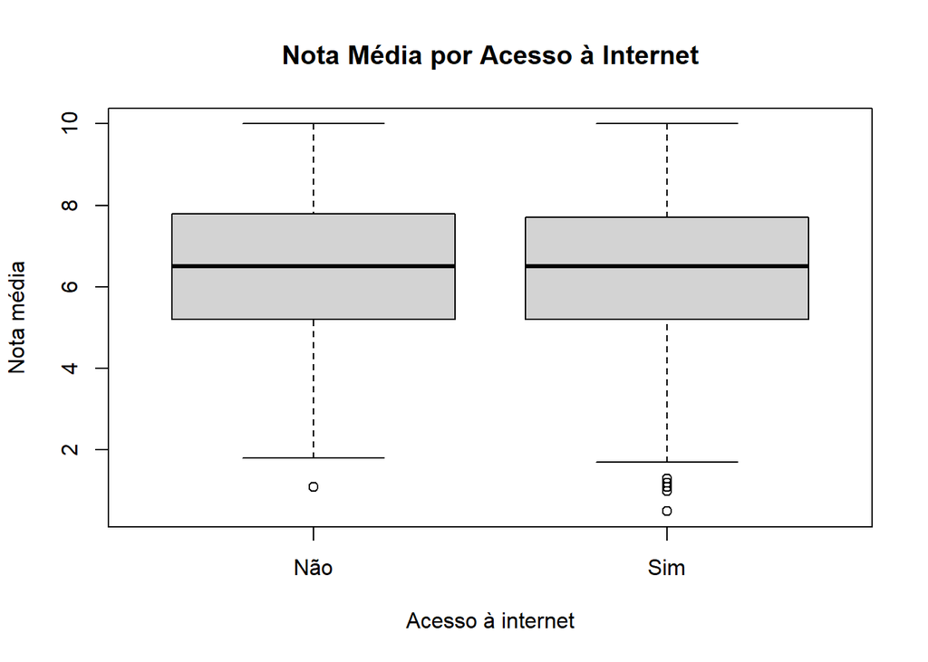

```r
boxplot(
  nota_media ~ acesso_internet,
  data = dados_alunos,
  main = "Nota Média por Acesso à Internet",
  xlab = "Acesso à internet",
  ylab = "Nota média"
)
```

Para verificar se a diferença entre as médias é estatisticamente significativa, será utilizado o teste t para duas amostras.

```r
teste_internet <- t.test(
  nota_media ~ acesso_internet,
  data = dados_alunos
)

teste_internet
```

```
##
##  Welch Two Sample t-test
##
## data:  nota_media by acesso_internet
## t = 0.41236, df = 549.34, p-value = 0.6802
## alternative hypothesis: true difference in means between group Não and group Sim is not equal to 0
## 95 percent confidence interval:
##  -0.2035329  0.3116928
## sample estimates:
## mean in group Não mean in group Sim
##          6.481818          6.427738
```

O valor de p é:

```r
teste_internet$p.value
```

```
## [1] 0.6802379
```

Considerando um nível de significância de 5%, temos:

```r
if (teste_internet$p.value < 0.05) {
  cat("O valor de p é menor que 0,05. Portanto, existem evidências estatísticas de diferença entre as notas médias dos alunos com e sem acesso à internet.")
} else {
  cat("O valor de p é maior ou igual a 0,05. Portanto, não existem evidências estatísticas suficientes para afirmar que as notas médias dos dois grupos sejam diferentes.")
}
```

```
## O valor de p é maior ou igual a 0,05. Portanto, não existem evidências estatísticas suficientes para afirmar que as notas médias dos dois grupos sejam diferentes.
```

Dessa forma, a comparação das médias juntamente com o teste t permite responder à questão sobre a relação entre acesso à internet e desempenho acadêmico.

## 4.2 4.2 Escolaridade da mãe e desempenho

A segunda questão investiga como a escolaridade da mãe se relaciona com o desempenho dos alunos.

Serão calculadas as médias das notas para cada nível de escolaridade materna.

```r
media_escolaridade <- tapply(
  dados_alunos$nota_media,
  dados_alunos$escolaridade_mae,
  mean,
  na.rm = TRUE
)

round(media_escolaridade, 2)
```

```
## Fundamental       Médio    Superior
##        6.33        6.55        6.41
```

As distribuições das notas serão comparadas por meio de boxplot.

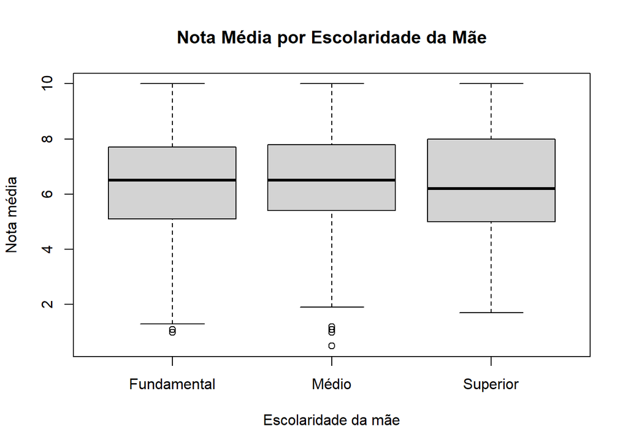

```r
boxplot(
  nota_media ~ escolaridade_mae,
  data = dados_alunos,
  main = "Nota Média por Escolaridade da Mãe",
  xlab = "Escolaridade da mãe",
  ylab = "Nota média"
)
```

Para verificar se existem diferenças estatisticamente significativas entre os grupos, será utilizada uma ANOVA.

```r
modelo_anova <- aov(
  nota_media ~ escolaridade_mae,
  data = dados_alunos
)

summary(modelo_anova)
```

```
##                   Df Sum Sq Mean Sq F value Pr(>F)
## escolaridade_mae   2     11   5.478   1.547  0.213
## Residuals        997   3529   3.540
```

O valor de p da ANOVA é:

```r
p_anova <- summary(modelo_anova)[[1]][["Pr(>F)"]][1]

p_anova
```

```
## [1] 0.2132956
```

Interpretação:

```r
if (p_anova < 0.05) {
  cat("O valor de p é menor que 0,05. Portanto, existem evidências estatísticas de diferença entre pelo menos dois grupos de escolaridade materna.")
} else {
  cat("O valor de p é maior ou igual a 0,05. Portanto, não existem evidências estatísticas suficientes de diferença entre as médias dos grupos de escolaridade materna.")
}
```

```
## O valor de p é maior ou igual a 0,05. Portanto, não existem evidências estatísticas suficientes de diferença entre as médias dos grupos de escolaridade materna.
```

A análise permite verificar se a escolaridade da mãe está associada a diferenças no desempenho acadêmico.

## 4.3 4.3 Número de faltas e nota média

A terceira questão procura verificar a relação entre frequência escolar e desempenho.

Será calculado o coeficiente de correlação de Pearson.

```r
correlacao <- cor(
  dados_alunos$faltas,
  dados_alunos$nota_media,
  use = "complete.obs"
)

correlacao
```

```
## [1] -0.01006418
```

O coeficiente encontrado foi **-0.01**.

Para visualizar a relação entre as duas variáveis:

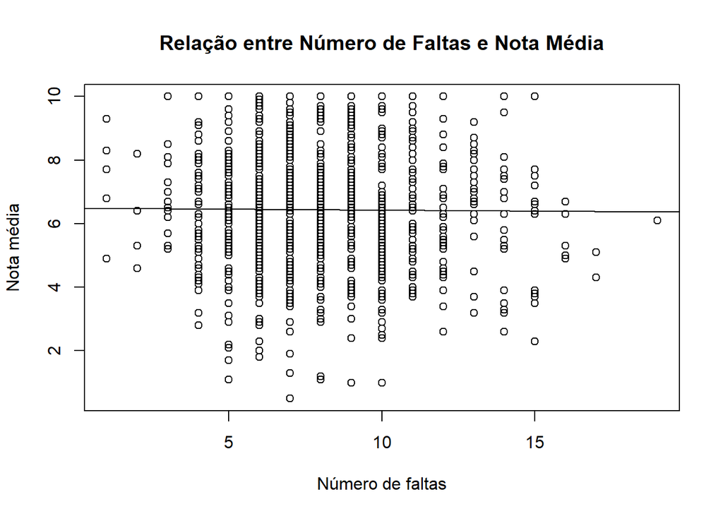

```r
plot(
  dados_alunos$faltas,
  dados_alunos$nota_media,
  main = "Relação entre Número de Faltas e Nota Média",
  xlab = "Número de faltas",
  ylab = "Nota média"
)

abline(
  lm(nota_media ~ faltas, data = dados_alunos)
)
```

Também será realizado o teste de correlação.

```r
teste_correlacao <- cor.test(
  dados_alunos$faltas,
  dados_alunos$nota_media
)

teste_correlacao
```

```
##
##  Pearson's product-moment correlation
##
## data:  dados_alunos$faltas and dados_alunos$nota_media
## t = -0.31796, df = 998, p-value = 0.7506
## alternative hypothesis: true correlation is not equal to 0
## 95 percent confidence interval:
##  -0.07201234  0.05196132
## sample estimates:
##         cor
## -0.01006418
```

A interpretação da direção da correlação é:

```r
if (correlacao < 0) {
  cat("A correlação é negativa. De modo geral, maiores números de faltas estão associados a menores notas médias.")
} else if (correlacao > 0) {
  cat("A correlação é positiva. De modo geral, maiores números de faltas estão associados a maiores notas médias.")
} else {
  cat("A correlação é próxima de zero, indicando pouca ou nenhuma associação linear entre faltas e nota média.")
}
```

[output not shown]

### 4.3.1 Análise da intensidade da correlação

```r
if (abs(correlacao) < 0.20) {
  cat("A associação linear é muito fraca.")
} else if (abs(correlacao) < 0.40) {
  cat("A associação linear é fraca.")
} else if (abs(correlacao) < 0.60) {
  cat("A associação linear é moderada.")
} else if (abs(correlacao) < 0.80) {
  cat("A associação linear é forte.")
} else {
  cat("A associação linear é muito forte.")
}
```

```
## A associação linear é muito fraca.
```

### 4.3.2 Investigação de um possível ponto crítico

Para investigar se existe uma faixa de faltas na qual o desempenho sofre uma redução mais acentuada, os alunos serão divididos em grupos.

```r
dados_alunos$faixa_faltas <- cut(
  dados_alunos$faltas,
  breaks = c(-Inf, 5, 10, 15, 20, Inf),
  labels = c(
    "0 a 5",
    "6 a 10",
    "11 a 15",
    "16 a 20",
    "Mais de 20"
  )
)
```

Serão calculadas as médias das notas em cada faixa.

```r
medias_faixas <- tapply(
  dados_alunos$nota_media,
  dados_alunos$faixa_faltas,
  mean,
  na.rm = TRUE
)

round(medias_faixas, 2)
```

```
##      0 a 5     6 a 10    11 a 15    16 a 20 Mais de 20
##       6.37       6.47       6.46       5.60         NA
```

As médias serão apresentadas graficamente.

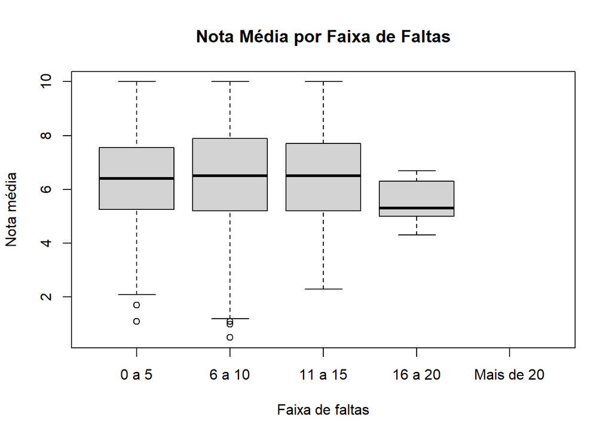

```r
boxplot(
  nota_media ~ faixa_faltas,
  data = dados_alunos,
  main = "Nota Média por Faixa de Faltas",
  xlab = "Faixa de faltas",
  ylab = "Nota média"
)
```

Essa comparação permite identificar se as notas apresentam redução à medida que aumenta o número de faltas.

## 4.4 4.4 Turno e número de faltas

A quarta questão investiga se os alunos do turno noturno apresentam maior número de faltas.

Serão calculadas as médias de faltas por turno.

```r
media_faltas_turno <- tapply(
  dados_alunos$faltas,
  dados_alunos$turno,
  mean,
  na.rm = TRUE
)

round(media_faltas_turno, 2)
```

```
##   Matutino    Noturno Vespertino
##       8.03       7.95       8.03
```

O resultado será apresentado por meio de um boxplot.

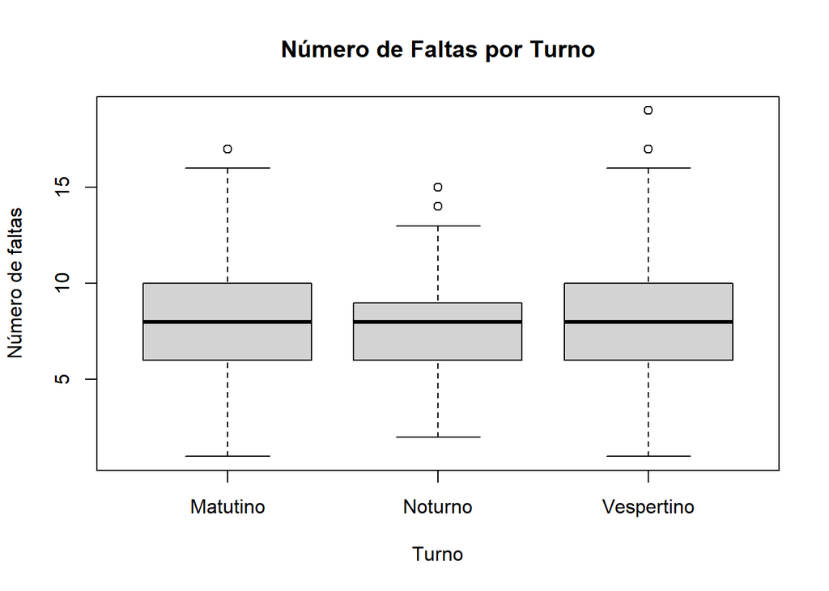

```r
boxplot(
  faltas ~ turno,
  data = dados_alunos,
  main = "Número de Faltas por Turno",
  xlab = "Turno",
  ylab = "Número de faltas"
)
```

O turno com maior média de faltas é:

```r
turno_maior_falta <- names(which.max(media_faltas_turno))

turno_maior_falta
```

```
## [1] "Matutino"
```

A maior média de faltas foi de **8.03 faltas**.

## 4.5 4.5 Turno e nota média

Também será analisado o desempenho dos alunos de acordo com o turno.

```r
media_nota_turno <- tapply(
  dados_alunos$nota_media,
  dados_alunos$turno,
  mean,
  na.rm = TRUE
)

round(media_nota_turno, 2)
```

```
##   Matutino    Noturno Vespertino
##       6.46       6.58       6.34
```

O resultado será apresentado graficamente.

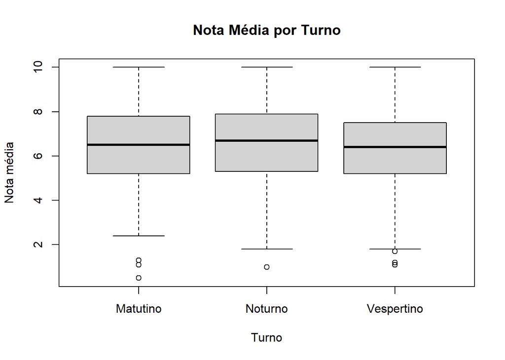

```r
boxplot(
  nota_media ~ turno,
  data = dados_alunos,
  main = "Nota Média por Turno",
  xlab = "Turno",
  ylab = "Nota média"
)
```

O turno com maior nota média foi **Noturno**, com média de **6.58**.

O turno com menor nota média foi **Vespertino**, com média de **6.34**.

# 5 5. Análise Multivariada

A análise multivariada permite considerar mais de duas variáveis simultaneamente.

Nesta etapa serão analisadas conjuntamente as variáveis turno, acesso à internet e nota média.

## 5.1 5.1 Turno, acesso à internet e nota média

Inicialmente serão calculadas as médias das notas para cada combinação de turno e acesso à internet.

```r
media_conjunta <- aggregate(
  nota_media ~ turno + acesso_internet,
  data = dados_alunos,
  FUN = mean
)

media_conjunta
```

```
##        turno acesso_internet nota_media
## 1   Matutino             Não   6.541353
## 2    Noturno             Não   6.861404
## 3 Vespertino             Não   6.205607
## 4   Matutino             Sim   6.427987
## 5    Noturno             Sim   6.477551
## 6 Vespertino             Sim   6.396639
```

O resultado também será apresentado graficamente.

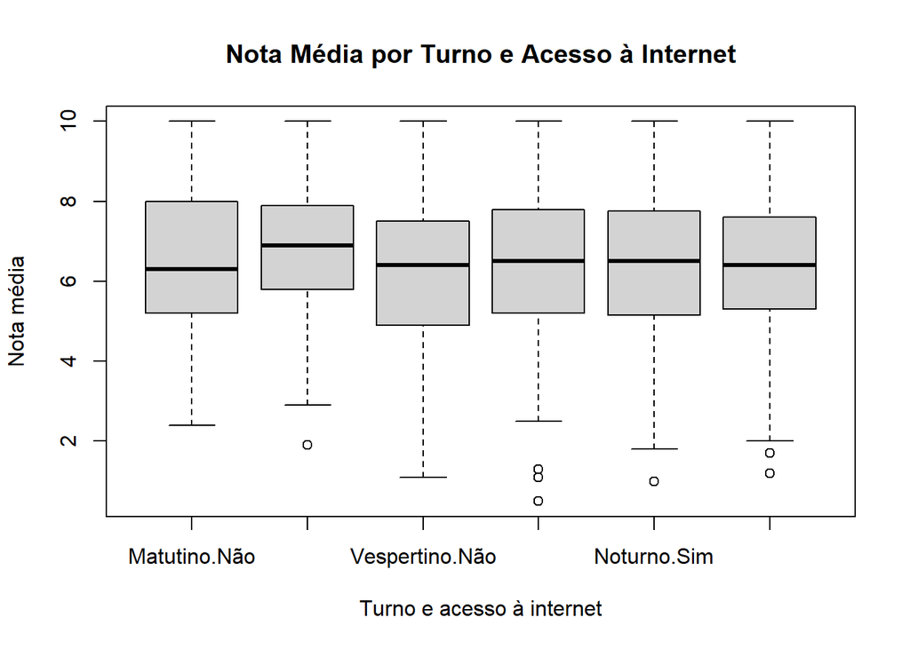

```r
boxplot(
  nota_media ~ interaction(turno, acesso_internet),
  data = dados_alunos,
  main = "Nota Média por Turno e Acesso à Internet",
  xlab = "Turno e acesso à internet",
  ylab = "Nota média"
)
```

A análise conjunta permite observar se o comportamento das notas varia de acordo com o turno e com o acesso à internet.

## 5.2 5.2 Escolaridade da mãe, acesso à internet e nota média

Também será analisada conjuntamente a relação entre escolaridade da mãe, acesso à internet e nota média.

```r
media_sociofamiliar <- aggregate(
  nota_media ~ escolaridade_mae + acesso_internet,
  data = dados_alunos,
  FUN = mean
)

media_sociofamiliar
```

```
##   escolaridade_mae acesso_internet nota_media
## 1      Fundamental             Não   6.351240
## 2            Médio             Não   6.535484
## 3         Superior             Não   6.657692
## 4      Fundamental             Sim   6.318148
## 5            Médio             Sim   6.560597
## 6         Superior             Sim   6.275510
```

Essa análise permite verificar se diferentes condições sociofamiliares estão associadas a diferentes níveis de desempenho acadêmico.

## 5.3 5.3 Modelo de regressão linear

Para investigar se as variáveis sociofamiliares e o número de faltas explicam parte da variabilidade das notas, será ajustado um modelo de regressão linear.

```r
modelo_regressao <- lm(
  nota_media ~ faltas + escolaridade_mae + acesso_internet + turno,
  data = dados_alunos
)

summary(modelo_regressao)
```

```
##
## Call:
## lm(formula = nota_media ~ faltas + escolaridade_mae + acesso_internet +
##     turno, data = dados_alunos)
##
## Residuals:
##     Min      1Q  Median      3Q     Max
## -6.0557 -1.2593  0.0225  1.3112  3.8040
##
## Coefficients:
##                           Estimate Std. Error t value Pr(>|t|)
## (Intercept)               6.425662   0.223852  28.705   <2e-16 ***
## faltas                   -0.004847   0.021347  -0.227   0.8204
## escolaridade_maeMédio     0.231216   0.129783   1.782   0.0751 .
## escolaridade_maeSuperior  0.094949   0.181737   0.522   0.6015
## acesso_internetSim       -0.067265   0.130863  -0.514   0.6074
## turnoNoturno              0.130076   0.159518   0.815   0.4150
## turnoVespertino          -0.123596   0.134681  -0.918   0.3590
## ---
## Signif. codes:  0 '***' 0.001 '**' 0.01 '*' 0.05 '.' 0.1 ' ' 1
##
## Residual standard error: 1.883 on 993 degrees of freedom
## Multiple R-squared:  0.00578,    Adjusted R-squared:  -0.0002277
## F-statistic: 0.9621 on 6 and 993 DF,  p-value: 0.4497
```

O modelo considera simultaneamente:

- número de faltas;
- escolaridade da mãe;
- acesso à internet;
- turno de estudo.

O coeficiente de determinação do modelo é:

```r
summary(modelo_regressao)$r.squared
```

```
## [1] 0.005779687
```

O valor de R² representa a proporção da variabilidade da nota média explicada conjuntamente pelas variáveis incluídas no modelo.

# 6 6. Síntese dos resultados

A análise estatística permitiu investigar diferentes aspectos do banco de dados.

A média de faltas dos alunos foi de **8.01**.

A nota média geral foi de **6.44 pontos**.

A correlação entre faltas e nota média foi de **-0.01**.

O teste t permitiu verificar se existe diferença estatisticamente significativa entre as notas dos alunos com e sem acesso à internet.

A ANOVA permitiu investigar possíveis diferenças nas notas de acordo com a escolaridade da mãe.

A análise multivariada permitiu considerar simultaneamente diferentes características dos alunos, possibilitando uma interpretação mais ampla dos dados.

# 7 7. Respostas às questões investigativas

## 7.1 Questão 1 – Relação entre infraestrutura e desempenho

A questão investigou se os alunos com acesso à internet em casa apresentam notas médias significativamente maiores.

As médias observadas foram:

```r
round(media_internet, 2)
```

```
##  Não  Sim
## 6.48 6.43
```

O valor de p do teste t foi **0.6802**.

```r
if (teste_internet$p.value < 0.05) {
  cat("Como o valor de p é menor que 0,05, há evidências estatísticas de diferença entre as notas médias dos alunos com e sem acesso à internet.")
} else {
  cat("Como o valor de p é maior ou igual a 0,05, não há evidências estatísticas suficientes para afirmar que exista diferença entre as notas médias dos alunos com e sem acesso à internet.")
}
```

```
## Como o valor de p é maior ou igual a 0,05, não há evidências estatísticas suficientes para afirmar que exista diferença entre as notas médias dos alunos com e sem acesso à internet.
```

Portanto, a resposta deve ser interpretada considerando tanto as médias observadas quanto o resultado do teste estatístico.

## 7.2 Questão 2 – Capital cultural e rendimento

A escolaridade da mãe foi relacionada ao desempenho dos alunos.

As médias das notas por escolaridade materna foram:

```r
round(media_escolaridade, 2)
```

```
## Fundamental       Médio    Superior
##        6.33        6.55        6.41
```

O valor de p da ANOVA foi **0.2133**.

```r
if (p_anova < 0.05) {
  cat("Existem evidências estatísticas de diferença entre pelo menos dois grupos de escolaridade materna.")
} else {
  cat("Não existem evidências estatísticas suficientes de diferença entre as médias dos grupos de escolaridade materna.")
}
```

```
## Não existem evidências estatísticas suficientes de diferença entre as médias dos grupos de escolaridade materna.
```

A análise permite verificar se existe uma relação entre escolaridade materna e rendimento acadêmico.

## 7.3 Questão 3 – Frequência e desempenho

A correlação entre número de faltas e nota média foi de **-0.01**.

```r
if (correlacao < 0) {
  cat("A associação é negativa, indicando que maiores números de faltas estão associados a menores notas médias.")
} else if (correlacao > 0) {
  cat("A associação é positiva, indicando que maiores números de faltas estão associados a maiores notas médias.")
} else {
  cat("A associação linear é próxima de zero.")
}
```

[output not shown]

A análise por faixas de faltas foi realizada para investigar se existe uma faixa na qual o desempenho apresenta redução mais acentuada.

As médias das notas por faixa foram:

```r
round(medias_faixas, 2)
```

```
##      0 a 5     6 a 10    11 a 15    16 a 20 Mais de 20
##       6.37       6.47       6.46       5.60         NA
```

Essa comparação permite identificar possíveis mudanças no comportamento das notas conforme aumenta o número de faltas.

## 7.4 Questão 4 – Perfil do aluno noturno

As médias de faltas por turno foram:

```r
round(media_faltas_turno, 2)
```

```
##   Matutino    Noturno Vespertino
##       8.03       7.95       8.03
```

O turno com maior média de faltas foi **Matutino**.

A maior média observada foi de **8.03 faltas**.

As médias das notas por turno foram:

```r
round(media_nota_turno, 2)
```

```
##   Matutino    Noturno Vespertino
##       6.46       6.58       6.34
```

O turno com maior nota média foi **Noturno**.

O turno com menor nota média foi **Vespertino**.

Dessa maneira, é possível comparar tanto a frequência quanto o desempenho entre os diferentes turnos.

## 7.5 Questão 5 – Desigualdades educacionais

As variáveis escolaridade da mãe e acesso à internet foram analisadas conjuntamente com a nota média.

```r
media_sociofamiliar
```

```
##   escolaridade_mae acesso_internet nota_media
## 1      Fundamental             Não   6.351240
## 2            Médio             Não   6.535484
## 3         Superior             Não   6.657692
## 4      Fundamental             Sim   6.318148
## 5            Médio             Sim   6.560597
## 6         Superior             Sim   6.275510
```

Também foi ajustado um modelo de regressão linear considerando faltas, escolaridade da mãe, acesso à internet e turno.

```r
summary(modelo_regressao)
```

```
##
## Call:
## lm(formula = nota_media ~ faltas + escolaridade_mae + acesso_internet +
##     turno, data = dados_alunos)
##
## Residuals:
##     Min      1Q  Median      3Q     Max
## -6.0557 -1.2593  0.0225  1.3112  3.8040
##
## Coefficients:
##                           Estimate Std. Error t value Pr(>|t|)
## (Intercept)               6.425662   0.223852  28.705   <2e-16 ***
## faltas                   -0.004847   0.021347  -0.227   0.8204
## escolaridade_maeMédio     0.231216   0.129783   1.782   0.0751 .
## escolaridade_maeSuperior  0.094949   0.181737   0.522   0.6015
## acesso_internetSim       -0.067265   0.130863  -0.514   0.6074
## turnoNoturno              0.130076   0.159518   0.815   0.4150
## turnoVespertino          -0.123596   0.134681  -0.918   0.3590
## ---
## Signif. codes:  0 '***' 0.001 '**' 0.01 '*' 0.05 '.' 0.1 ' ' 1
##
## Residual standard error: 1.883 on 993 degrees of freedom
## Multiple R-squared:  0.00578,    Adjusted R-squared:  -0.0002277
## F-statistic: 0.9621 on 6 and 993 DF,  p-value: 0.4497
```

O coeficiente de determinação foi:

```r
summary(modelo_regressao)$r.squared
```

```
## [1] 0.005779687
```

Esse resultado permite avaliar quanto da variabilidade das notas pode ser explicada conjuntamente pelas variáveis utilizadas no modelo.

É importante destacar que uma associação estatística não significa necessariamente uma relação de causa e efeito.

## 7.6 Questão 6 – Análise por subgrupos

Considerando conjuntamente turno e acesso à internet, foram calculadas as médias das notas.

```r
media_conjunta
```

```
##        turno acesso_internet nota_media
## 1   Matutino             Não   6.541353
## 2    Noturno             Não   6.861404
## 3 Vespertino             Não   6.205607
## 4   Matutino             Sim   6.427987
## 5    Noturno             Sim   6.477551
## 6 Vespertino             Sim   6.396639
```

Essa análise permite observar padrões específicos entre os diferentes subgrupos de alunos.

# 8 8. Conclusão

A análise estatística do banco de dados permitiu explorar informações de 1.000 alunos e investigar relações entre frequência escolar, desempenho acadêmico e características sociofamiliares.

Na análise univariada, foram estudadas individualmente as cinco variáveis do banco. Para as variáveis quantitativas foram calculadas medidas como média, mediana e desvio-padrão. Para as variáveis qualitativas foram apresentadas frequências, percentuais e gráficos.

Na análise bivariada, foram investigadas as relações entre acesso à internet e desempenho, escolaridade da mãe e nota média, número de faltas e desempenho, além das diferenças entre os turnos.

A relação entre número de faltas e nota média apresentou coeficiente de correlação igual a **-0.01**.

Também foi realizada uma análise por faixas de faltas para verificar possíveis alterações mais acentuadas no desempenho conforme aumenta o número de ausências.

A análise multivariada permitiu considerar simultaneamente turno, acesso à internet, escolaridade da mãe, faltas e nota média.

De maneira geral, o estudo demonstra a importância da estatística para compreender fenômenos educacionais e identificar padrões nos dados.

# 9 9. Limitações da análise

A análise apresenta algumas limitações.

Primeiramente, o banco de dados possui apenas cinco variáveis, portanto diversos fatores que podem influenciar o desempenho escolar não foram considerados.

Além disso, as análises realizadas identificam associações entre as variáveis, mas não permitem estabelecer relações de causa e efeito.

Também é importante considerar que o banco foi construído para uma situação de pesquisa simulada e, portanto, seus resultados não devem ser generalizados para todas as escolas públicas brasileiras.

# 10 10. Possibilidades de pesquisas futuras

Em pesquisas futuras, seria interessante incluir outras variáveis, como idade, série escolar, renda familiar, condições de transporte, participação dos responsáveis na vida escolar, histórico de notas, condições da escola e outras características relacionadas ao contexto educacional.

A inclusão dessas informações poderia permitir análises estatísticas mais aprofundadas e contribuir para uma compreensão mais ampla dos fatores associados ao desempenho acadêmico.

# 11 11. Considerações finais

A realização deste trabalho possibilitou aplicar conceitos de estatística descritiva, análise bivariada e análise multivariada em um contexto educacional.

Além de calcular medidas estatísticas e construir gráficos, foi possível interpretar os resultados e investigar questões relacionadas à frequência escolar, desempenho acadêmico e condições sociofamiliares.

A utilização de testes estatísticos, correlação e regressão possibilitou ampliar a análise para além da simples descrição dos dados.

Dessa forma, o trabalho demonstra que a estatística pode ser utilizada como instrumento de investigação e reflexão sobre problemas educacionais, contribuindo para uma melhor compreensão dos dados e para a tomada de decisões fundamentadas.

# 12 Referências bibliograficas

BENÊVIDE, B. **Probabilidade e Estatística – PROFMAT/CA/UFSJ**. Universidade Federal de São João del-Rei, 2026. Disponível em: https://bendeivide.github.io/courses/profmat-probest/normal2026.2/. Acesso em: 14 set. 2026.

BENÊVIDE, B. **Epaec – Estatística e Probabilidade Aplicada à Educação**. Disponível em: https://bendeivide.github.io/books/epaec/. Acesso em: 14 set. 2026.

OPENAI. **ChatGPT**. Ferramenta de inteligência artificial utilizada como apoio à elaboração, organização e revisão do relatório. Disponível em: https://chatgpt.com/. Acesso em: 14 set. 2026.

SANTOS, Flávia Alves dos Anjos. **Relatório 2 – Análise Estatística**. 2026. Disponível em: https://flaviaalves-profmat.github.io/Relatorio/rel02/index.html. Acesso em: 14 set. 2026.